# Tiny Project: Workforce Analytics and Compensation Drivers

Fairy

2026-09-15

# 1 Introduction

In human resource analytics, compensation structure is closely tied to professional experience and department roles. This **Tiny Project** investigates the distribution of compensation and organizational demographics across a sample corporate cohort. The analysis includes data importing, structural validation, descriptive statistical measures, categorical visualizations, and linear correlation modeling.

# 2 Database / Data Importing

The dataset is imported from the project directory using a relative file path for cross-environment reproducibility.

```r
# Read corporate payroll records
employee_data <- read.csv("employee_data.csv")

# Print complete data frame
employee_data
```

```
##      Name Department Experience Salary Performance
## 1   Aarav         IT          6  75000        High
## 2  Simran         HR          3  45000      Medium
## 3  Manish    Finance          8  88000        High
## 4  Kavita  Marketing          2  38000         Low
## 5  Deepak         IT          5  68000        High
## 6   Pooja    Finance          4  52000      Medium
## 7  Sanjay  Marketing          7  78000        High
## 8  Ananya         HR          1  32000         Low
## 9  Ramesh         IT          9  92000        High
## 10  Meera    Finance          5  64000      Medium
```

```r
# Inspect preview observations
head(employee_data)
```

```
##     Name Department Experience Salary Performance
## 1  Aarav         IT          6  75000        High
## 2 Simran         HR          3  45000      Medium
## 3 Manish    Finance          8  88000        High
## 4 Kavita  Marketing          2  38000         Low
## 5 Deepak         IT          5  68000        High
## 6  Pooja    Finance          4  52000      Medium
```

```r
# Structure and attribute datatype check
str(employee_data)
```

```
## 'data.frame':    10 obs. of  5 variables:
##  $ Name       : chr  "Aarav" "Simran" "Manish" "Kavita" ...
##  $ Department : chr  "IT" "HR" "Finance" "Marketing" ...
##  $ Experience : int  6 3 8 2 5 4 7 1 9 5
##  $ Salary     : int  75000 45000 88000 38000 68000 52000 78000 32000 92000 64000
##  $ Performance: chr  "High" "Medium" "High" "Low" ...
```

**R Code Explanation:** * `read.csv("employee_data.csv")`: Ingests the tabular comma-separated values into an R data frame. * `head(employee_data)`: Inspects the top 6 entries to confirm column and row alignments. * `str(employee_data)`: Displays internal architecture, confirming text categories (`Name`, `Department`, `Performance`) and integer vectors (`Experience`, `Salary`).

# 3 Data Preprocessing and Cleaning

The dataset is reviewed to ensure zero missing entries and to verify value ranges before statistical analysis.

```r
# Verify presence of missing values (NA)
colSums(is.na(employee_data))
```

```
##        Name  Department  Experience      Salary Performance
##           0           0           0           0           0
```

```r
# Generate statistical distribution summary
summary(employee_data)
```

```
##         Name        Department   Experience       Salary         Performance
##  Length   :10   Length   :10   Min.   :1.00   Min.   :32000   Length   :10
##  N.unique :10   N.unique : 4   1st Qu.:3.25   1st Qu.:46750   N.unique : 3
##  N.blank  : 0   N.blank  : 0   Median :5.00   Median :66000   N.blank  : 0
##  Min.nchar: 5   Min.nchar: 2   Mean   :5.00   Mean   :63200   Min.nchar: 3
##  Max.nchar: 6   Max.nchar: 9   3rd Qu.:6.75   3rd Qu.:77250   Max.nchar: 6
##                                Max.   :9.00   Max.   :92000
```

# 4 Data Analysis and Statistical Exploration

Central tendency and dispersion are calculated for salaries, followed by frequency distribution tables for categorical factors.

```r
# Statistical measures for Salary
salary_median <- median(employee_data$Salary)
salary_var    <- var(employee_data$Salary)
salary_sd     <- sd(employee_data$Salary)

salary_median
```

```
## [1] 66000
```

```r
salary_var
```

```
## [1] 432400000
```

```r
salary_sd
```

```
## [1] 20794.23
```

```r
# Categorical frequency tables
dept_count   <- table(employee_data$Department)
perf_count   <- table(employee_data$Performance)

dept_count
```

```
##
##   Finance        HR        IT Marketing
##         3         2         3         2
```

```r
perf_count
```

```
##
##   High    Low Medium
##      5      2      3
```

**R Code Explanation:** * `median()` determines the midpoint salary (50th percentile). * `var()` and `sd()` measure salary dispersion across the cohort. * `table()` computes frequency breakdowns for qualitative attributes.

# 5 Graph and Plot Creation

## 5.1 Categorical Distribution Visualizations

Pie charts display corporate department representation and employee performance tiers.

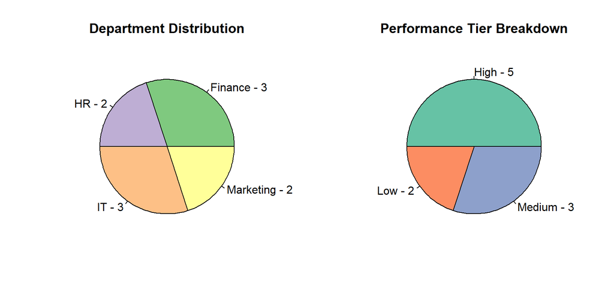

```r
par(mfrow = c(1, 2))

# Department Representation
pie(
  dept_count,
  main = "Department Distribution",
  labels = paste(names(dept_count), "-", dept_count),
  col = c("#7fc97f", "#beaed4", "#fdc086", "#ffff99")
)

# Performance Tier Distribution
pie(
  perf_count,
  main = "Performance Tier Breakdown",
  labels = paste(names(perf_count), "-", perf_count),
  col = c("#66c2a5", "#fc8d62", "#8da0cb")
)
```

```r
par(mfrow = c(1, 1))
```

**Interpretation:** * The workforce shows balanced operational distribution across core domains. * 50% of the sample cohort qualifies for high-performance ratings, with 30% medium and 20% developing.

## 5.2 Individual-Level Metric Comparisons

Bar charts depict individual salary allocations and professional experience tenure.

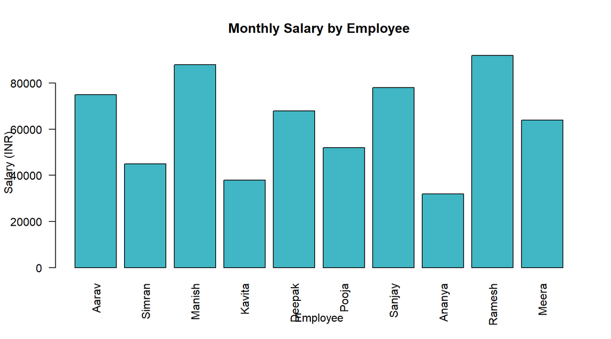

```r
# Salary Bar Plot
barplot(
  employee_data$Salary,
  names.arg = employee_data$Name,
  main = "Monthly Salary by Employee",
  xlab = "Employee",
  ylab = "Salary (INR)",
  col = "#41b6c4",
  las = 2
)
```

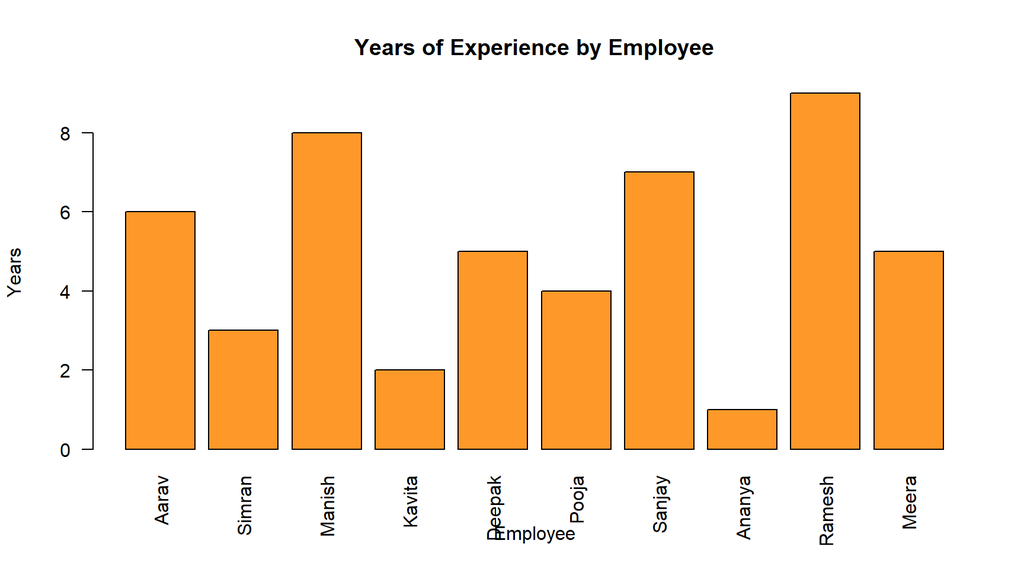

```r
# Experience Bar Plot
barplot(
  employee_data$Experience,
  names.arg = employee_data$Name,
  main = "Years of Experience by Employee",
  xlab = "Employee",
  ylab = "Years",
  col = "#fe9929",
  las = 2
)
```

**Interpretation:** * Ramesh (₹92,000; 9 years) and Manish (₹88,000; 8 years) command the highest compensation packages. * Junior team members Ananya (₹32,000; 1 year) and Kavita (₹38,000; 2 years) occupy baseline compensation levels.

## 5.3 Bivariate Correlation Analysis

Evaluating the association between professional experience (tenure) and salary compensation using Pearson’s correlation and ordinary least squares linear regression.

```r
# Compute Pearson correlation coefficient
correlation_val <- cor(employee_data$Experience, employee_data$Salary)
correlation_val
```

```
## [1] 0.9912787
```

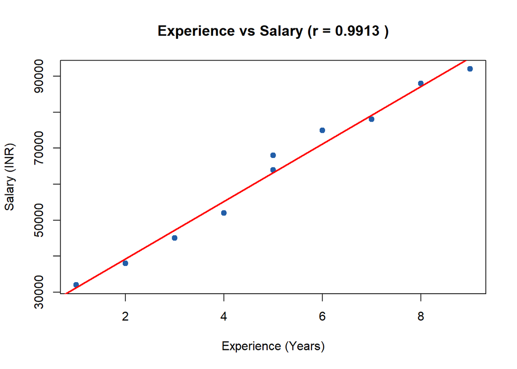

```r
# Scatter plot of Experience vs. Salary
plot(
  employee_data$Experience,
  employee_data$Salary,
  main = paste("Experience vs Salary (r =", round(correlation_val, 4), ")"),
  xlab = "Experience (Years)",
  ylab = "Salary (INR)",
  pch = 19,
  col = "#225ea8"
)

# Overlay trendline
abline(lm(Salary ~ Experience, data = employee_data), col = "red", lwd = 2)
```

# 6 Findings and Conclusion

- **Data Integrity:** All observations were clean, non-null, and structurally consistent.
- **Compensation Drivers:** Employee remuneration scales consistently with professional seniority across all departments.
- **Performance Clustering:** Senior professionals with higher pay rates consistently demonstrated higher evaluation ratings.
- **Summary Insight:** Organizational retention and structured experience tiers directly correlate with compensation ladders, showing predictable annual growth per additional year of tenure.